# Time to Play Uniform

(a) You by no means are required to sketch the Uniform distribution with R. Below is the code that will enable you to do so.

```r
#provides the distribution of the measurement error
curve(dunif(x,min = -0.05, max = 0.05), -0.05, 0.05, xlim=c(-0.07,0.07), ylim=c(0,12), xlab = "Values of X", ylab="f(x)", xaxt="n", main="Distribution of Measurement Errors", type="l", col='red')
axis(1, at=c(-0.05, -0.025, 0, 0.025, 0.05), labels=c(-0.05,-0.025, 0, 0.025, 0.05))
```

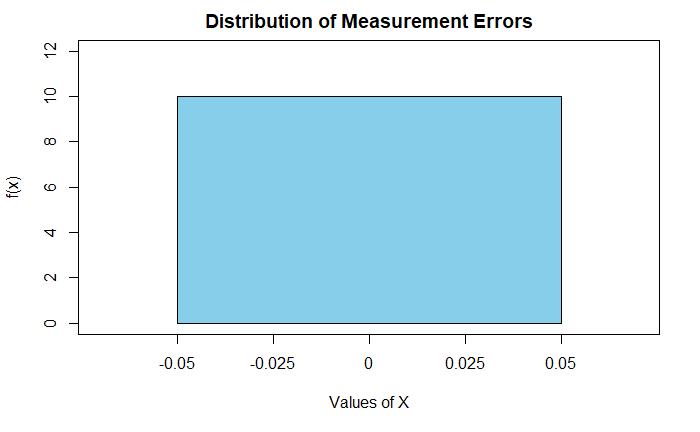

```r
x.cor = c(-0.05, seq(-0.05, 0.05, 0.01), 0.05)
y.cor = c(0, dunif(seq(-0.05, 0.05, 0.01),min = -0.05, max = 0.05), 0)
polygon(x.cor, y.cor,col='skyblue')
```

2. The probability density function $f(x)$ and the cumulative distribution function $F(x)$ are given respectively as
   $$f(x) = \left \{
   \begin{array}{ll}
   \frac{1}{0.05 - (-0.05)} = 10& {\rm for\:\:} -0.05 \leq x \leq 0.05 \\
   0 & {\rm otherwise} \\
   \end{array}
   \right.$$
   The **cumulative distribution function** of a Uniformly distributed random variable, $P(X \leq X)$, is also given
   $$F(x) = \left \{
   \begin{array}{ll}
   0 & {\rm for\:\;} x < -0.05 \\
   \frac{x + 0.05}{0.05 - (-0.05)} & {\rm for\:\:} -0.05 \leq x < 0.05 \\
   1 & {\rm for \:\:} x \geq 0.05 \\
   \end{array}
   \right.$$
3. If the measurement is complete accurate, then $X = 0$. To be accurate to within 0.02 $\mu$s, the measurement must be $\pm$ 0.02 from 0, which requires you to compute $P(|X - 0.02| \leq 0) = P(0 - 0.02 \leq X \leq 0 + 0.02) = P(-0.02 \leq X \leq 0.02)$. Using any means necessary this probabilty is computed to be
   $$\begin{aligned}
   P(-0.02 \leq X \leq 0.02) = & \int_{-0.02}^{0.02}\left(\frac{1}{0.10}\right)dx \\
   = & 10*(0.02 - (-0.02)) \\
   = & 10*(0.04) \\
   = & 0.40
   \end{aligned}$$
   or
   $$\begin{aligned}
   P(-0.02 \leq X \leq 0.02) = & P(X \leq 0.02) - P(X \leq -0.02) \\
   = & F(0.02) - F(-0.02) \\
   = & \left(\frac{0.02 + 0.05}{0.10}\right) - \left(\frac{-0.02 + 0.05}{0.10}\right) \\
   = & \frac{0.04}{0.10} \\
   = & 0.40
   \end{aligned}$$
   This probabilty can be computed with the R code

```r
punif(0.02, -0.05, 0.05) - punif(-0.02, -0.05, 0.05)
```

```
[1] 0.4
```

4. The median value of $X$, or the median measurement error, is $x_{50}$. This is computed with
   $$\begin{aligned}
   0.50 = & P(X \leq x_{50}) \\
   0.50 = & \left(\frac{x_{50} - (-0.05)}{0.05 - (-0.05)}\right) \\
   0.50 * (0.10) = & x_{50} + 0.05 \\
   0.05 - 0.05 = & x_{50} \\
   0 \:\:\mu\text{s} = X_{50}
   \end{aligned}$$
   The median measurement error is $0$ $\mu$s.
5. The mean measurement error is
   $$\mu_{X} = E(X) = \frac{-0.05 + 0.05}{2} = 0 \: \mu\text{S}$$

```r
(-0.05 + 0.05)/2
```

```
[1] 0
```

Notice in this instance that the $median* value of $X$ and the $\mu_{X}$ are the same value? This occurs in the Uniform distribution, which is perfectly symmetrical around both the $\mu_{X}$ and the median $x_{50}$.

6. The standard deviation in the measurement error is computed as
   $$\sigma_{X} = SD(X) = \sqrt{\frac{(b - a)^{2}}{12}} = \sqrt{\frac{(0.05 - (-0.05))^{2}}{12}} = 0.028867 \approx 0.0289 \:\:\mu\text{s}$$

```r
sqrt(((0.05 - (-0.05))^{2})/12)
```

```
[1] 0.02886751
```

7. If the measurment error is within 0.02 $\mu$S, then $-0.02 \leq X \leq 0.02$ has occurred. *Given* this, you wish to compute
   $$\begin{aligned}
   P(-0.005 \leq X \leq 0.005|-0.02 \leq X \leq 0.02) = & \frac{P(-0.005 \leq X \leq 0.005 \cap-0.02 \leq X \leq 0.02)}{P(-0.02 \leq X \leq 0.02)} \\
   = & \frac{P(-0.005 \leq X \leq 0.005)}{P(-0.02 \leq X \leq 0.02)} \\
   \end{aligned}$$
   This is represented in the graph below:

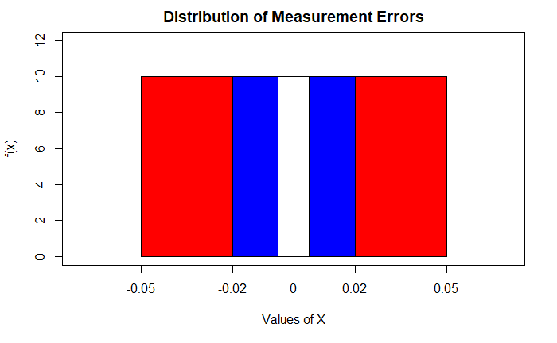

```r
(punif(0.005, -0.05, 0.05) - punif(-0.005, -0.05, 0.05))/(punif(0.02, -0.05, 0.05) - punif(-0.02, -0.05, 0.05))
```

```
[1] 0.25
```